# PA1_template

# 8. Histogram of the total number of steps taken each day after missing values are imputed

[figure not shown]

```r
library(lattice)

histogram(fd4$x,fd4,xlab="total steps/day",ylab="% share",main="Total Steps [Oct-Dec]",col="orange")
```

the histogram shows gradual increase in activity pattern from 0-13000 intervals and form a bell curve, which is different from what we have seen earlier before imputing missing “NA” values especially at intial 0-2000 steps levels.

# 9. Panel plot comparing the average number of steps taken per 5-minute interval across weekdays and weekends

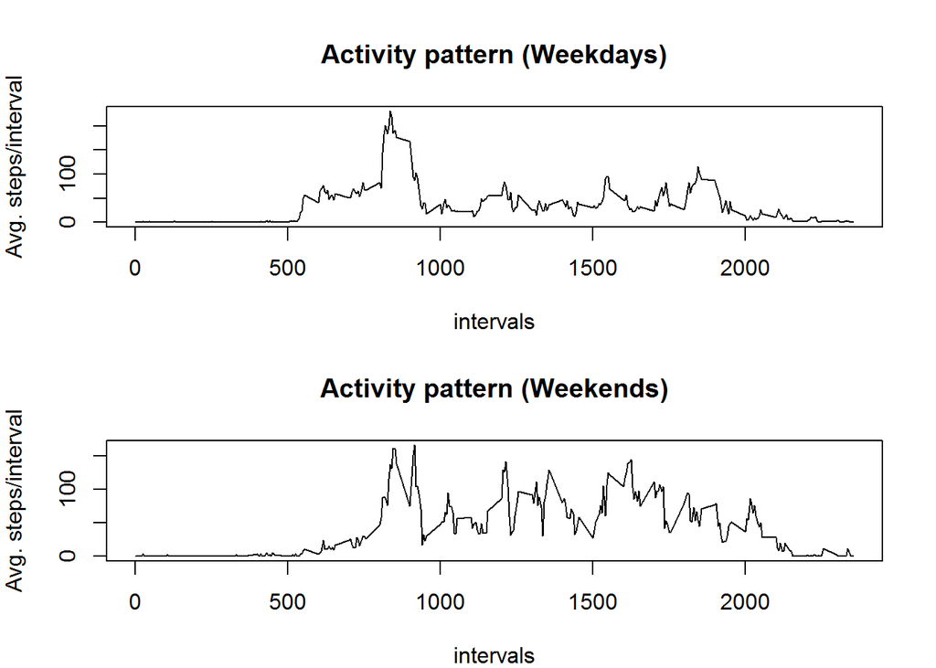

```r
fd$day<-weekdays(fd$date)

for(j in 1:length(fd$steps)){

  if(!is.null(fd[j,4]) && fd[j,4]=="Saturday" | fd[j,4]=="Sunday"){
    h<-"Weekend"
    fd[j,4]<-h
    }else {
    h<-"Weekday"
    fd[j,4]<-h
    }
    fd
}

# Weekday activity pattern data
fd5<-subset(fd,fd$day=="Weekday")
fd5<-aggregate(fd5$steps,FUN=mean,by=list(fd5$day,fd5$interval))

# Weekend activity pattern data
fd6<-subset(fd,fd$day=="Weekend")
fd6<-aggregate(fd6$steps,FUN=mean,by=list(fd6$day,fd6$interval))

# panel plots for comparison
par(mfrow=c(2,1),mar=c(4,4,4,2))

# Weekdays plot
plot(fd5$Group.2,fd5$x,type="l",xlab="intervals",ylab="Avg. steps/interval",main="Activity pattern (Weekdays)")

# Weekends plot
plot(fd6$Group.2,fd6$x,type="l",xlab="intervals",ylab="Avg. steps/interval",main="Activity pattern (Weekends)")
```

After comparison, it is clear that average steps taken were more in weekends then weekdays, which is quite uniformly distributed then in weekdays.

[output not shown]